# Esercitazione: burnout e supporto sociale al lavoro

Soluzioni

# 1 Il contesto

Un’azienda di medie dimensioni ha chiesto al servizio di psicologia del lavoro di indagare il benessere dei propri dipendenti. A 200 dipendenti è stato somministrato un questionario che misura:

- l’**esaurimento emotivo**, una delle componenti del burnout;
- il **supporto sociale percepito** da parte di colleghi e superiori, considerato un possibile fattore di protezione.

Sono stati inoltre raccolti alcuni dati socio-anagrafici e lavorativi. I dati sono nel file `benessere_lavoro.csv`.

| Variabile | Descrizione |
| --- | --- |
| `id` | codice identificativo del dipendente |
| `genere` | genere del dipendente (`F`, `M`) |
| `eta` | età in anni |
| `anni_servizio` | anni di servizio nell’azienda |
| `anzianita` | anzianità in azienda: `junior` (fino a 3 anni), `intermedio` (da 4 a 6 anni), `senior` (più di 6 anni) |
| `titolo_studio` | titolo di studio più alto: `diploma`, `laurea triennale`, `laurea magistrale` |
| `reparto` | reparto di appartenenza: `amministrazione`, `produzione`, `commerciale`, `risorse umane` |
| `supporto_sociale` | punteggio di supporto sociale percepito (da 1 a 7; punteggi alti = più supporto) |
| `burnout` | punteggio di esaurimento emotivo (da 0 a 54; punteggi alti = più esaurimento) |

# 2 Importazione e preparazione dei dati

## 2.1

*Salvare il file `benessere_lavoro.csv` nella cartella `data` del progetto e importarlo in un oggetto chiamato `dati`. Nel file le colonne sono separate da `;` e i decimali da `,`. La scelta della funzione usata per importare il dataset dipende da questi dettagli.*

Le colonne sono separate da punto e virgola e i decimali sono indicati con la virgola: la funzione adatta è `read.csv2()`, che ha già questi valori come default (`sep = ";"`, `dec = ","`).

```r
dati = read.csv2("data/benessere_lavoro.csv")
```

## 2.2

*Esaminare la struttura del dataset. Quanti dipendenti sono presenti nel dataset? Quante informazioni sono state raccolte su ciascuno?*

```r
str(dati)
```

```
'data.frame':   200 obs. of  9 variables:
 $ id              : int  1 2 3 4 5 6 7 8 9 10 ...
 $ genere          : chr  "M" "M" "F" "F" ...
 $ eta             : int  48 32 44 48 42 38 29 47 45 37 ...
 $ anni_servizio   : int  12 6 12 15 17 5 3 11 20 14 ...
 $ anzianita       : chr  "senior" "intermedio" "senior" "senior" ...
 $ titolo_studio   : chr  "laurea magistrale" "diploma" "laurea triennale" "laurea magistrale" ...
 $ reparto         : chr  "produzione" "amministrazione" "commerciale" "amministrazione" ...
 $ supporto_sociale: num  3.4 4.1 2.8 4.9 4.6 3.2 5.5 5.5 2.9 2.9 ...
 $ burnout         : int  31 21 27 28 44 26 16 25 39 33 ...
```

```r
nrow(dati)
```

```
[1] 200
```

```r
ncol(dati)
```

```
[1] 9
```

Nel dataset ci sono 200 dipendenti (le righe) e su ciascuno sono state raccolte 9 informazioni (le colonne), compreso il codice identificativo `id`.

## 2.3

**Per ogni variabile del dataset dichiarare di che tipo di variabile si tratta** (qualitativa o quantitativa; per le qualitative, nominale od ordinale; per le quantitative, discreta o continua) e su quale scala di misura è rilevata.

| Variabile | Tipo | Scala di misura |
| --- | --- | --- |
| `id` | qualitativa (è solo un’etichetta che identifica il dipendente, non va analizzata) | nominale |
| `genere` | qualitativa | nominale |
| `eta` | quantitativa discreta (età in anni compiuti) | a rapporti |
| `anni_servizio` | quantitativa discreta | a rapporti |
| `anzianita` | qualitativa | ordinale |
| `titolo_studio` | qualitativa | ordinale |
| `reparto` | qualitativa | nominale |
| `supporto_sociale` | quantitativa continua (punteggio con decimali) | a intervalli |
| `burnout` | quantitativa discreta (punteggio intero) | a intervalli |

`anzianita` è ottenuta raggruppando in classi la variabile `anni_servizio`: passando dagli anni alle classi si perde informazione e si scende da una scala a rapporti a una scala ordinale.

## 2.4

*Confrontare il tipo di ciascuna variabile con il modo in cui R l’ha importata. Trasformare le variabili che non sono state importate nel modo adeguato, rispettando l’ordine dei livelli quando esiste un ordine naturale (vedi la tabella di descrizione del dataset).*

Dalla struttura si vede che le variabili quantitative sono state importate correttamente come numeriche (`int` o `num`), mentre le variabili qualitative `genere`, `anzianita`, `titolo_studio` e `reparto` sono state importate come stringhe di caratteri (`chr`) e vanno trasformate in factor.

Per `genere` e `reparto` (nominali) l’ordine dei livelli non è rilevante:

```r
dati$genere = factor(dati$genere)
dati$reparto = factor(dati$reparto)
```

Per `anzianita` e `titolo_studio` (ordinali) l’ordine va specificato con l’argomento `levels`.

```r
levels(factor(dati$anzianita))
```

```
[1] "intermedio" "junior"     "senior"
```

```r
levels(factor(dati$titolo_studio))
```

```
[1] "diploma"           "laurea magistrale" "laurea triennale"
```

```r
dati$anzianita = factor(dati$anzianita,
                        levels = c("junior", "intermedio", "senior"))
dati$titolo_studio = factor(dati$titolo_studio,
                            levels = c("diploma", "laurea triennale", "laurea magistrale"))
```

## 2.5

*Verificare che le trasformazioni abbiano funzionato e che i livelli siano nell’ordine corretto.*

```r
str(dati)
```

```
'data.frame':   200 obs. of  9 variables:
 $ id              : int  1 2 3 4 5 6 7 8 9 10 ...
 $ genere          : Factor w/ 2 levels "F","M": 2 2 1 1 1 2 1 1 2 2 ...
 $ eta             : int  48 32 44 48 42 38 29 47 45 37 ...
 $ anni_servizio   : int  12 6 12 15 17 5 3 11 20 14 ...
 $ anzianita       : Factor w/ 3 levels "junior","intermedio",..: 3 2 3 3 3 2 1 3 3 3 ...
 $ titolo_studio   : Factor w/ 3 levels "diploma","laurea triennale",..: 3 1 2 3 1 1 2 2 3 2 ...
 $ reparto         : Factor w/ 4 levels "amministrazione",..: 3 1 2 1 3 1 1 1 1 1 ...
 $ supporto_sociale: num  3.4 4.1 2.8 4.9 4.6 3.2 5.5 5.5 2.9 2.9 ...
 $ burnout         : int  31 21 27 28 44 26 16 25 39 33 ...
```

```r
levels(dati$anzianita)
```

```
[1] "junior"     "intermedio" "senior"
```

```r
levels(dati$titolo_studio)
```

```
[1] "diploma"           "laurea triennale"  "laurea magistrale"
```

Le quattro variabili sono ora factor e i livelli delle variabili ordinali sono nell’ordine corretto.

# 3 Descrizione del campione

## 3.1

*Come sono distribuiti i dipendenti tra uomini e donne? Rappresentare graficamente la distribuzione.*

`genere` è una variabile nominale: si descrive con le frequenze assolute e relative e si rappresenta con un grafico a barre.

```r
freq_genere = table(dati$genere)
freq_genere
```

```
  F   M
117  83
```

```r
(freq_genere/sum(freq_genere)) * 100
```

```
   F    M
58.5 41.5
```

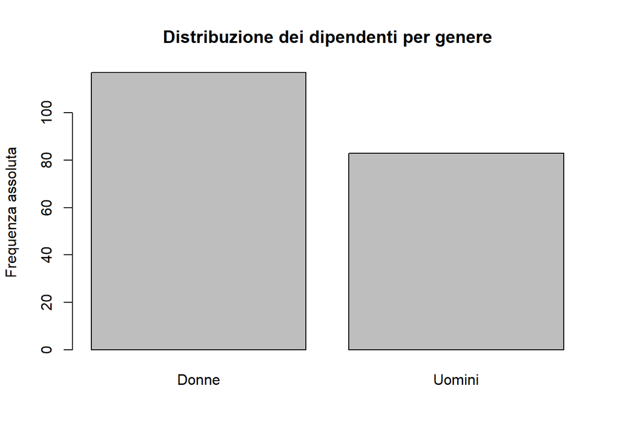

```r
barplot(freq_genere,
        names.arg = c("Donne", "Uomini"),
        ylab = "Frequenza assoluta",
        main = "Distribuzione dei dipendenti per genere")
```

Nel campione ci sono 117 donne (58.5%) e 83 uomini (41.5%).

## 3.2

*Qual è il reparto con più dipendenti? Che percentuale dei dipendenti lavora in questo reparto? Rappresentare graficamente la distribuzione percentuale.*

Il reparto con più dipendenti è la moda della variabile `reparto`, cioè la modalità con la frequenza più alta.

```r
freq_reparto = table(dati$reparto)
perc_reparto = (freq_reparto/sum(freq_reparto)) * 100
freq_reparto
```

```
amministrazione     commerciale      produzione   risorse umane
             59              47              52              42
```

```r
round(perc_reparto, 1)
```

```
amministrazione     commerciale      produzione   risorse umane
           29.5            23.5            26.0            21.0
```

```r
names(freq_reparto)[freq_reparto == max(freq_reparto)]
```

```
[1] "amministrazione"
```

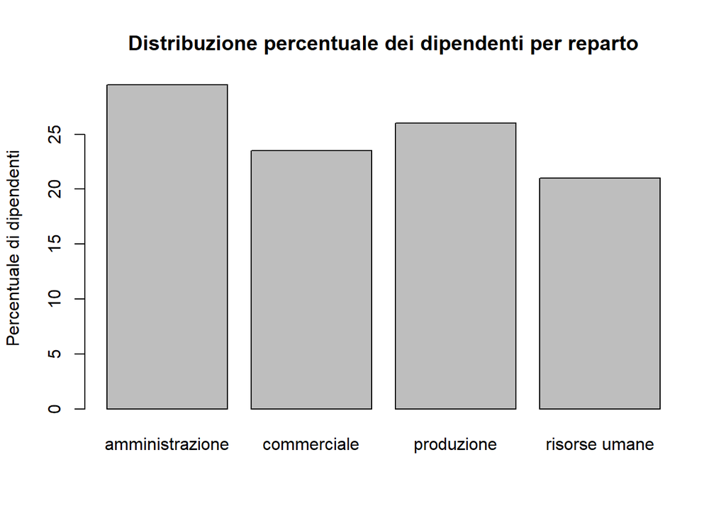

```r
barplot(perc_reparto,
        ylab = "Percentuale di dipendenti",
        main = "Distribuzione percentuale dei dipendenti per reparto")
```

Il reparto con più dipendenti è amministrazione, in cui lavora il 29.5% dei dipendenti.

## 3.3

*Come sono distribuiti i dipendenti nei tre livelli di anzianità? Rappresentare graficamente la distribuzione con il grafico più adatto.*

`anzianita` è una variabile ordinale: si usa un grafico a barre, con le barre nell’ordine naturale dei livelli (garantito dalla trasformazione in factor fatta prima).

```r
freq_anz = table(dati$anzianita)
freq_anz
```

```
    junior intermedio     senior
        72         64         64
```

```r
round((freq_anz/sum(freq_anz)) * 100, 1)
```

```
    junior intermedio     senior
        36         32         32
```

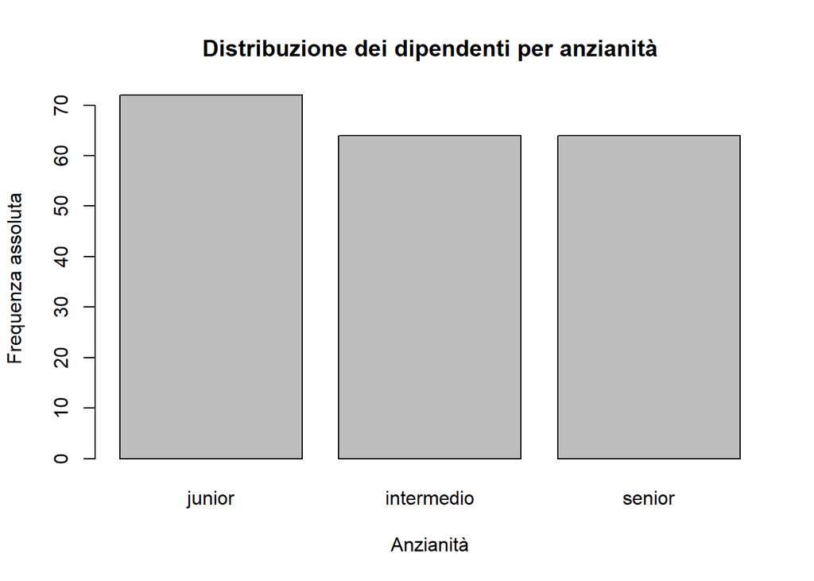

```r
barplot(freq_anz,
        xlab = "Anzianità",
        ylab = "Frequenza assoluta",
        main = "Distribuzione dei dipendenti per anzianità")
```

I dipendenti sono distribuiti in modo abbastanza equilibrato nei tre livelli, con un numero leggermente più alto di junior (72).

## 3.4

*Che percentuale di dipendenti ha al massimo la laurea triennale? Che percentuale ha almeno la laurea triennale?*

Per una variabile ordinale queste informazioni si ricavano dalle frequenze relative cumulate.

```r
perc_titolo = (table(dati$titolo_studio)/sum(table(dati$titolo_studio))) * 100
perc_titolo
```

```
          diploma  laurea triennale laurea magistrale
             26.5              38.5              35.0
```

```r
perc_cum = cumsum(perc_titolo)
perc_cum
```

```
          diploma  laurea triennale laurea magistrale
             26.5              65.0             100.0
```

“Al massimo la laurea triennale” significa diploma o laurea triennale: è la percentuale cumulata fino alla laurea triennale, cioè il 65%.

“Almeno la laurea triennale” significa laurea triennale o laurea magistrale: si ottiene togliendo da 100 la percentuale di chi ha solo il diploma.

```r
100 - perc_cum["diploma"]
```

```
diploma
   73.5
```

```r
# oppure
perc_titolo["laurea triennale"] + perc_titolo["laurea magistrale"]
```

```
laurea triennale
            73.5
```

Ha almeno la laurea triennale il 73.5% dei dipendenti.

## 3.5

*Qual è l’età tipica dei dipendenti dell’azienda? Qual è l’età del dipendente più giovane e di quello più anziano? Rappresentare graficamente la distribuzione della variabile.*

L’età è una variabile quantitativa: il valore tipico si descrive con media e mediana, e la distribuzione si rappresenta con un istogramma.

```r
mean(dati$eta)
```

```
[1] 37.265
```

```r
median(dati$eta); quantile(dati$eta, prob = .50) # stesso risultato
```

```
[1] 38
```

```
50%
 38
```

```r
min(dati$eta)
```

```
[1] 24
```

```r
max(dati$eta)
```

```
[1] 57
```

```r
# oppure, tutto insieme
summary(dati$eta)
```

```
   Min. 1st Qu.  Median    Mean 3rd Qu.    Max.
  24.00   31.75   38.00   37.27   42.00   57.00
```

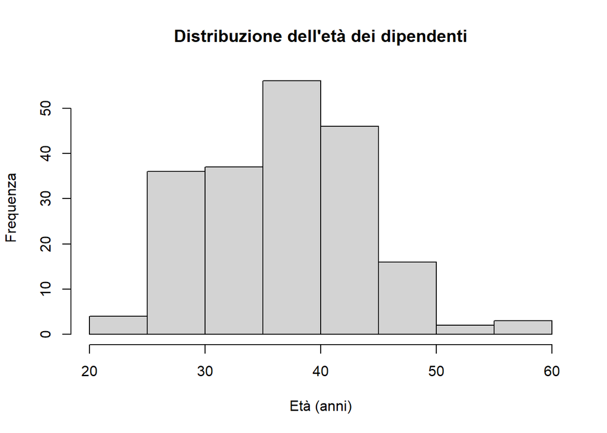

```r
hist(dati$eta,
     xlab = "Età (anni)",
     ylab = "Frequenza",
     main = "Distribuzione dell'età dei dipendenti")
```

L’età media dei dipendenti è 37.26 anni e la mediana è 38 anni: i due valori sono vicini, coerentemente con una distribuzione abbastanza simmetrica. Il dipendente più giovane ha 24 anni, il più anziano 57.

## 3.6

*Qual è il numero di anni di servizio medio in azienda? Rappresentare graficamente la distribuzione della variabile.*

```r
mean(dati$anni_servizio)
```

```
[1] 6.435
```

```r
median(dati$anni_servizio)
```

```
[1] 5
```

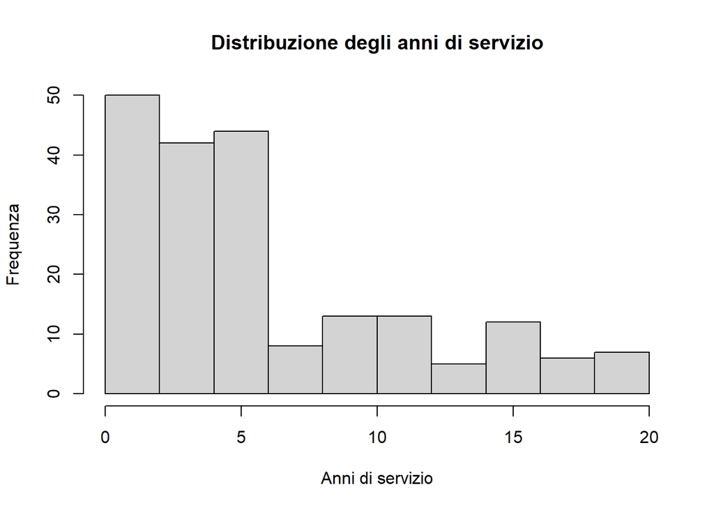

```r
hist(dati$anni_servizio,
     xlab = "Anni di servizio",
     ylab = "Frequenza",
     main = "Distribuzione degli anni di servizio")
```

In media i dipendenti lavorano in azienda da 6.43 anni. La distribuzione è asimmetrica a destra: molti dipendenti hanno pochi anni di servizio e pochi ne hanno molti. Per questo la media è più alta della mediana (5 anni), perché risente dei valori alti. In questo caso la mediana descrive meglio il valore tipico.

## 3.7

*Rappresentare graficamente la distribuzione quantilica dell’età delle dipendenti e dei dipendenti. Calcolare la loro età media.*

La distribuzione quantilica si rappresenta con il boxplot, che riporta minimo, quartili e massimo (ed eventuali valori anomali).

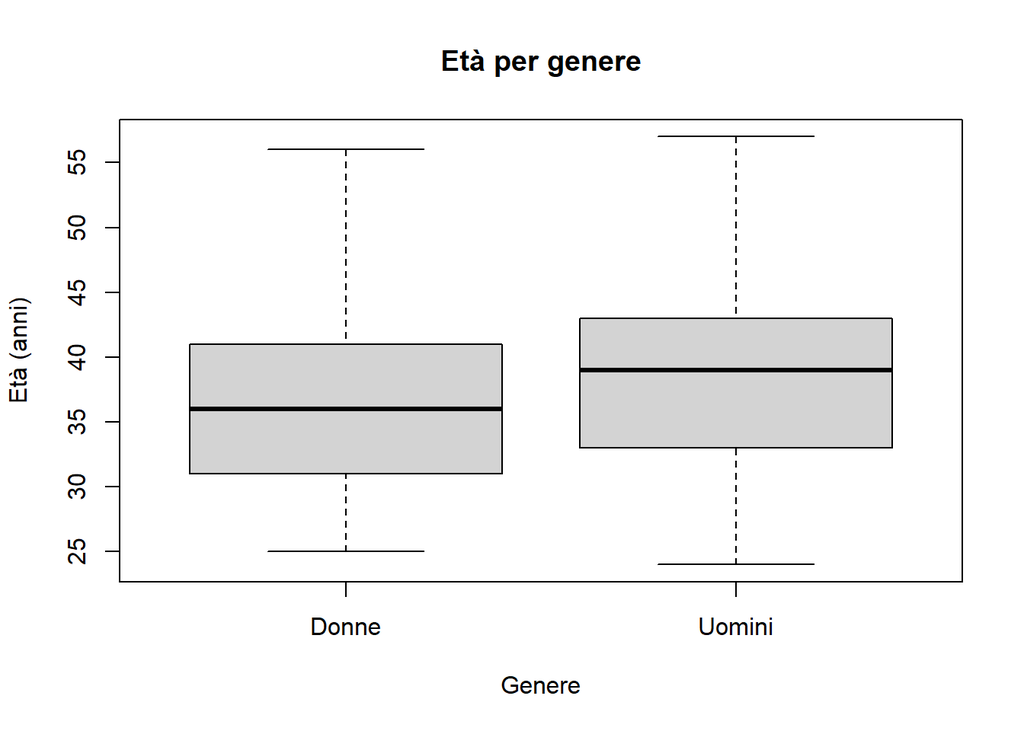

```r
boxplot(dati$eta ~ dati$genere,
        names = c("Donne", "Uomini"),
        xlab = "Genere",
        ylab = "Età (anni)",
        main = "Età per genere")
```

```r
mean(dati$eta[dati$genere == "F"])
```

```
[1] 36.5641
```

```r
mean(dati$eta[dati$genere == "M"])
```

```
[1] 38.25301
```

Le dipendenti hanno in media 36.56 anni, i dipendenti 38.25. Dal boxplot si vede che la distribuzione dell’età degli uomini è spostata leggermente verso l’alto rispetto a quella delle donne, ma la variabilità è simile nei due gruppi.

# 4 Burnout e supporto sociale

## 4.1

*Qual è il livello tipico di burnout dei dipendenti? E di supporto sociale percepito? Rappresentare graficamente le due variabili. Identificare anche eventuali valori estremi.*

```r
summary(dati$burnout)
```

```
   Min. 1st Qu.  Median    Mean 3rd Qu.    Max.
   0.00   16.00   21.00   21.37   27.00   47.00
```

```r
summary(dati$supporto_sociale)
```

```
   Min. 1st Qu.  Median    Mean 3rd Qu.    Max.
  1.900   3.900   4.600   4.584   5.325   7.000
```

Il punteggio medio di burnout è 21.37 (mediana 21), il punteggio medio di supporto sociale è 4.58 (mediana 4.6). In entrambi i casi media e mediana sono molto vicine.

Per rappresentare le due variabili e individuare i valori estremi si usano istogramma e boxplot:

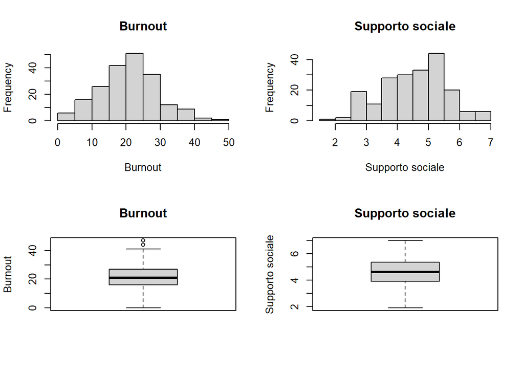

```r
par(mfrow = c(2, 2)) # crea una finestra grafica con due righe
# e due colonne per disporre i 4 grafici
hist(dati$burnout, xlab = "Burnout", main = "Burnout")
hist(dati$supporto_sociale, xlab = "Supporto sociale", main = "Supporto sociale")
boxplot(dati$burnout, ylab = "Burnout", main = "Burnout")
boxplot(dati$supporto_sociale, ylab = "Supporto sociale", main = "Supporto sociale")
```

```r
par(mfrow = c(1, 1)) # fa tornare a posto la finestra grafica
```

I valori estremi sono i punti rappresentati oltre i baffi del boxplot (più distanti di 1.5 volte la differenza interquartile dal primo o dal terzo quartile).

Per il burnout ci sono 2 valori estremi verso l’alto ( i due punti oltre il baffo superiore nel grafico), mentre per il supporto sociale non ci sono valori estremi.

## 4.2

*Il 25% dei dipendenti con il burnout più basso ha un punteggio inferiore a quale valore? Il 25% dei dipendenti con il burnout più alto ha un punteggio superiore a quale valore? Aiutarsi con la rappresentazione grafica appropriata.*

I valori richiesti sono il primo e il terzo quartile.

```r
q_burnout = quantile(dati$burnout, probs = c(0.25, 0.75))
q_burnout
```

```
25% 75%
 16  27
```

Il 25% dei dipendenti con il burnout più basso ha un punteggio inferiore a 16 (primo quartile); il 25% con il burnout più alto ha un punteggio superiore a 27 (terzo quartile).

## 4.3

*Entro quale intervallo di punteggi si colloca il 50% centrale dei dipendenti per il burnout? E per il supporto sociale? Quanto è ampio questo intervallo nei due casi?*

Il 50% centrale delle osservazioni è compreso tra il primo e il terzo quartile; l’ampiezza dell’intervallo è la differenza interquartile.

```r
q_supporto = quantile(dati$supporto_sociale, probs = c(0.25, 0.75))
q_burnout
```

```
25% 75%
 16  27
```

```r
q_supporto
```

```
  25%   75%
3.900 5.325
```

```r
IQR(dati$burnout)
```

```
[1] 11
```

```r
IQR(dati$supporto_sociale)
```

```
[1] 1.425
```

```r
# oppure
q_burnout[2] - q_burnout[1]
```

```
75%
 11
```

```r
q_supporto[2] - q_supporto[1]
```

```
  75%
1.425
```

Il 50% centrale dei dipendenti ha un punteggio di burnout tra 16 e 27 (intervallo ampio 11 punti) e un punteggio di supporto sociale tra 3.9 e 5.325 (intervallo ampio 1.42 punti). Le due ampiezze non si possono confrontare direttamente, perché le due variabili sono misurate su scale diverse (0–54 e 1–7).

## 4.4

*Il 10% dei dipendenti che percepisce meno supporto sociale ha un punteggio inferiore a quale valore? Il 10% che ne percepisce di più ha un punteggio superiore a quale valore?*

I valori richiesti sono il 10° e il 90° percentile.

```r
p_supporto = quantile(dati$supporto_sociale, probs = c(0.10, 0.90))
p_supporto
```

```
10% 90%
3.0 5.8
```

Il 10% dei dipendenti che percepisce meno supporto ha un punteggio inferiore a 3, il 10% che ne percepisce di più ha un punteggio superiore a 5.8.

# 5 Il burnout nei diversi gruppi

## 5.1

*Rappresentare graficamente la distribuzione quantilica del burnout delle dipendenti e dei dipendenti. Calcolare i punteggi medi a seconda del gruppo di appartenenza.*

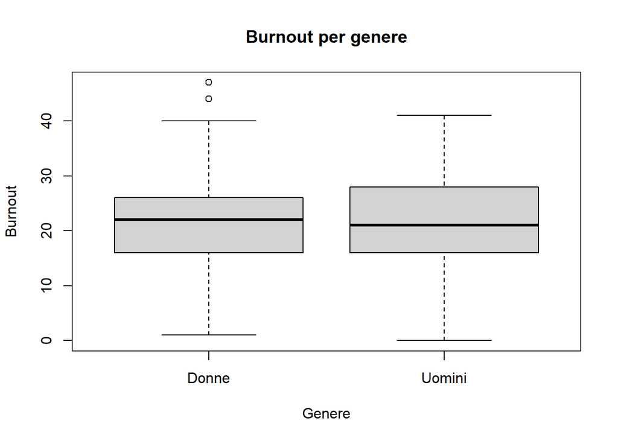

```r
boxplot(dati$burnout[dati$genere == "F"], dati$burnout[dati$genere == "M"],
        names = c("Donne", "Uomini"),
        xlab = "Genere",
        ylab = "Burnout",
        main = "Burnout per genere")
```

```r
# oppure
boxplot(dati$burnout ~ dati$genere,
        names = c("Donne", "Uomini"),
        xlab = "Genere",
        ylab = "Burnout",
        main = "Burnout per genere")


mean(dati$burnout[dati$genere == "F"])
```

```
[1] 21.20513
```

```r
mean(dati$burnout[dati$genere == "M"])
```

```
[1] 21.60241
```

Il punteggio medio di burnout è 21.21 per le donne e 21.6 per gli uomini. Le medie sono molto simili e le due scatole del boxplot si sovrappongono quasi completamente: il burnout non sembra cambiare con il genere. Nel gruppo delle donne ci sono due valori estremi verso l’alto.

## 5.2

*Ripetere le analisi del punto precedente considerando i livelli di anzianità.*

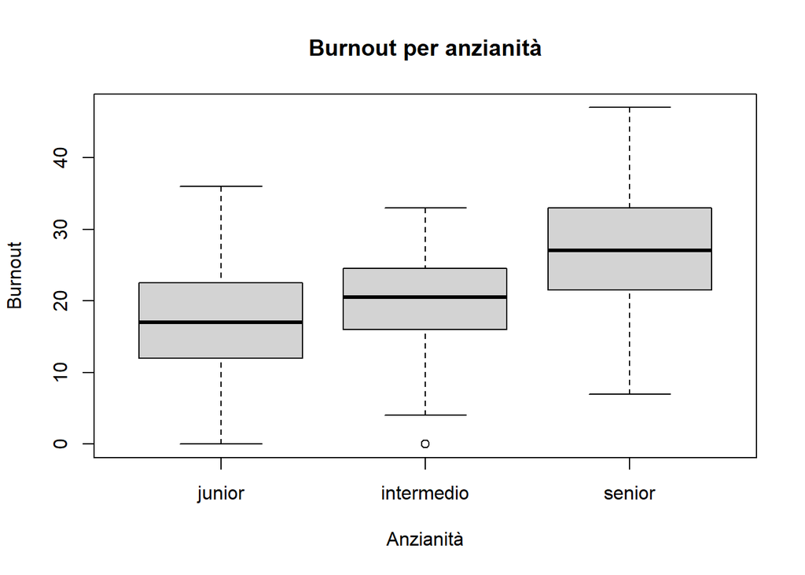

```r
boxplot(dati$burnout[dati$anzianita == "junior"],
        dati$burnout[dati$anzianita == "intermedio"],
        dati$burnout[dati$anzianita == "senior"],
        names = levels(dati$anzianita),
        xlab = "Anzianità",
        ylab = "Burnout",
        main = "Burnout per anzianità")
```

```r
# oppure
boxplot(dati$burnout ~ dati$anzianita,
        xlab = "Anzianità",
        ylab = "Burnout",
        main = "Burnout per anzianità")

mean(dati$burnout[dati$anzianita == "junior"])
```

```
[1] 17.69444
```

```r
mean(dati$burnout[dati$anzianita == "intermedio"])
```

```
[1] 19.65625
```

```r
mean(dati$burnout[dati$anzianita == "senior"])
```

```
[1] 27.21875
```

Il burnout medio dei senior (27.22) è più alto di quello di junior (17.69) e intermedi (19.66). Dal boxplot si vede che la mediana dei senior è più alta del terzo quartile degli junior: la distribuzione del burnout dei senior è spostata verso l’alto.

## 5.3

*Ripetere le analisi dei due punti precedenti considerando la variabile **supporto sociale**.*

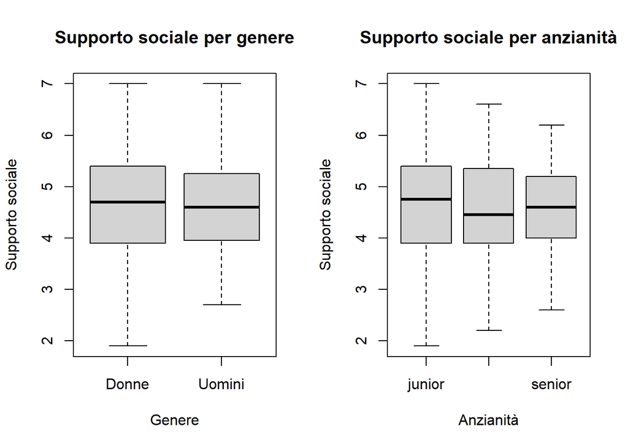

```r
par(mfrow = c(1, 2))
boxplot(dati$supporto_sociale ~ dati$genere,
        names = c("Donne", "Uomini"),
        xlab = "Genere",
        ylab = "Supporto sociale",
        main = "Supporto sociale per genere")
boxplot(dati$supporto_sociale ~ dati$anzianita,
        xlab = "Anzianità",
        ylab = "Supporto sociale",
        main = "Supporto sociale per anzianità")
```

```r
par(mfrow = c(1, 1))

mean(dati$supporto_sociale[dati$genere == "F"])
```

```
[1] 4.588034
```

```r
mean(dati$supporto_sociale[dati$genere == "M"])
```

```
[1] 4.578313
```

```r
mean(dati$supporto_sociale[dati$anzianita == "junior"])
```

```
[1] 4.702778
```

```r
mean(dati$supporto_sociale[dati$anzianita == "intermedio"])
```

```
[1] 4.539062
```

```r
mean(dati$supporto_sociale[dati$anzianita == "senior"])
```

```
[1] 4.495312
```

Il supporto sociale medio è praticamente uguale per donne e uomini e cambia poco nei tre livelli di anzianità: le distribuzioni si sovrappongono molto. A differenza del burnout, il supporto sociale non sembra dipendere né dal genere né dall’anzianità.

# 6 Punteggi di cut-off

## 6.1

*Creare una nuova variabile `burnout_alto` nel dataset, con valore `">=27"` se il punteggio di burnout è maggiore o uguale a 27 e `"<27"` altrimenti. Trasformarla nel tipo adeguato, con i livelli nell’ordine `"<27"`, `">=27"`. Verificare che la nuova variabile sia stata creata correttamente.*

```r
dati$burnout_alto = rep("<27", nrow(dati))
dati$burnout_alto[dati$burnout >= 27] = ">=27"
dati$burnout_alto = factor(dati$burnout_alto,
                           levels = c("<27", ">=27"))
```

Per verificare la nuova variabile si controllano i livelli e il valore minimo e massimo di `burnout` in ciascun gruppo: nel gruppo `"<27"` il massimo deve essere al più 26, nel gruppo `">=27"` il minimo deve essere 27.

```r
str(dati$burnout_alto)
```

```
 Factor w/ 2 levels "<27",">=27": 2 1 2 2 2 1 1 1 2 2 ...
```

```r
levels(dati$burnout_alto)
```

```
[1] "<27"  ">=27"
```

```r
max(dati$burnout[dati$burnout_alto == "<27"]) <= 26
```

```
[1] TRUE
```

```r
min(dati$burnout[dati$burnout_alto == ">=27"]) >= 27
```

```
[1] TRUE
```

## 6.2

*Quanti dipendenti hanno un livello di burnout alto? Che percentuale del totale rappresentano?*

```r
freq_alto = table(dati$burnout_alto)
freq_alto
```

```
 <27 >=27
 149   51
```

```r
(freq_alto/sum(freq_alto)) * 100
```

```
 <27 >=27
74.5 25.5
```

Hanno un livello di burnout alto 51 dipendenti, il 25.5% del totale.

## 6.3

*Che percentuale dei dipendenti è senior **e** ha un livello di burnout alto?*

È una frequenza relativa congiunta: si calcola sulla tabella di contingenza dividendo ogni cella per il totale dei dipendenti.

```r
tab_anz = table(dati$anzianita, dati$burnout_alto)
tab_anz
```

```
             <27 >=27
  junior      61   11
  intermedio  58    6
  senior      30   34
```

```r
addmargins(tab_anz)
```

```
             <27 >=27 Sum
  junior      61   11  72
  intermedio  58    6  64
  senior      30   34  64
  Sum        149   51 200
```

```r
(tab_anz/sum(tab_anz)) * 100
```

```
              <27 >=27
  junior     30.5  5.5
  intermedio 29.0  3.0
  senior     15.0 17.0
```

È senior e ha un burnout alto il 17% dei dipendenti.

## 6.4

*Tra i dipendenti junior, che percentuale ha un livello di burnout alto? E tra gli intermedi e i senior? Rappresentare graficamente il confronto.*

Qui la percentuale va calcolata all’interno di ciascun livello di anzianità: sono le frequenze relative condizionate di riga, $P(\text{burnout alto} | \text{anzianità})$.

```r
perc_anz = prop.table(tab_anz, 1) * 100
round(perc_anz, 1)
```

```
              <27 >=27
  junior     84.7 15.3
  intermedio 90.6  9.4
  senior     46.9 53.1
```

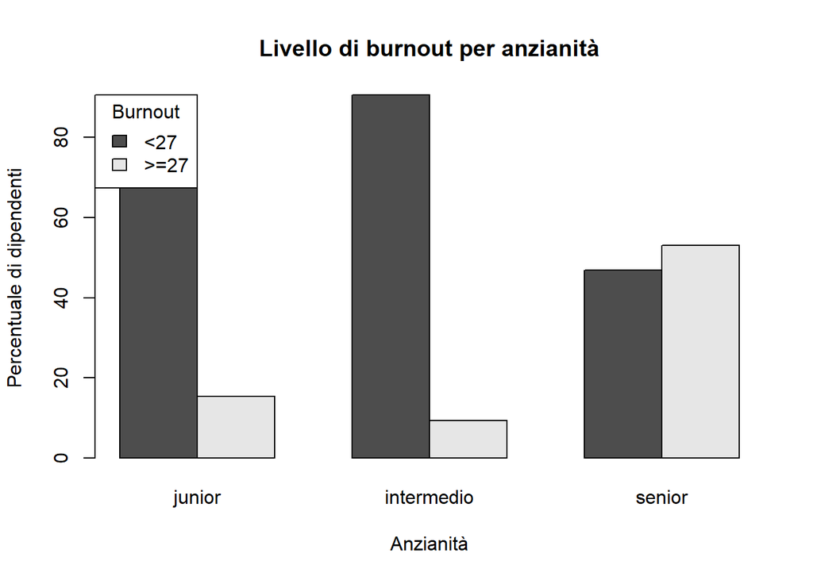

```r
barplot(t(perc_anz),
        beside = TRUE,
        legend.text = TRUE,
        args.legend = list(title = "Burnout", x = "topleft"),
        xlab = "Anzianità",
        ylab = "Percentuale di dipendenti",
        main = "Livello di burnout per anzianità")
```

Ha un burnout alto il 15.3% degli junior, il 9.4% degli intermedi e il 53.1% dei senior. Tra i senior più di un dipendente su due ha un livello di burnout alto.

## 6.5

*C’è associazione tra anzianità e livello di burnout? Utilizzare gli indici appropriati.*

Per l’associazione tra due variabili qualitative si usa il $\chi^2$, che confronta le frequenze osservate con quelle attese nel caso di indipendenza. Dato che il valore del $\chi^2$ dipende dalla numerosità e dalla dimensione della tabella, lo si normalizza dividendolo per il suo valore massimo:

$$\chi^2_N = \dfrac{\chi^2}{N \times \min[(r-1); (c-1)]}$$

```r
chi2_anz = chisq.test(tab_anz)$statistic
chi2_anz
```

```
X-squared
 38.42903
```

```r
chi2max_anz = nrow(dati) * min(dim(tab_anz) - 1)
chi2max_anz
```

```
[1] 200
```

```r
chi2norm_anz = chi2_anz / chi2max_anz
chi2norm_anz
```

```
X-squared
0.1921452
```

Le frequenze attese nel caso di indipendenza si possono vedere con:

```r
chisq.test(tab_anz)$expected
```

```
               <27  >=27
  junior     53.64 18.36
  intermedio 47.68 16.32
  senior     47.68 16.32
```

Tra i senior si osservano molti più dipendenti con burnout alto di quelli attesi in caso di indipendenza (34 contro 16.3). Il $\chi^2$ è 38.43 e il $\chi^2$ normalizzato è 0.192: c’è un’associazione tra anzianità e livello di burnout, dovuta soprattutto alla percentuale molto più alta di burnout alto tra i senior.

## 6.6

*C’è associazione tra genere e livello di burnout? Precedere il calcolo della statistica con l’opportuna rappresentazione grafica.*

```r
tab_gen = table(dati$genere, dati$burnout_alto)
addmargins(tab_gen)
```

```
      <27 >=27 Sum
  F    91   26 117
  M    58   25  83
  Sum 149   51 200
```

```r
perc_gen = prop.table(tab_gen, 1) * 100
round(perc_gen, 1)
```

```
     <27 >=27
  F 77.8 22.2
  M 69.9 30.1
```

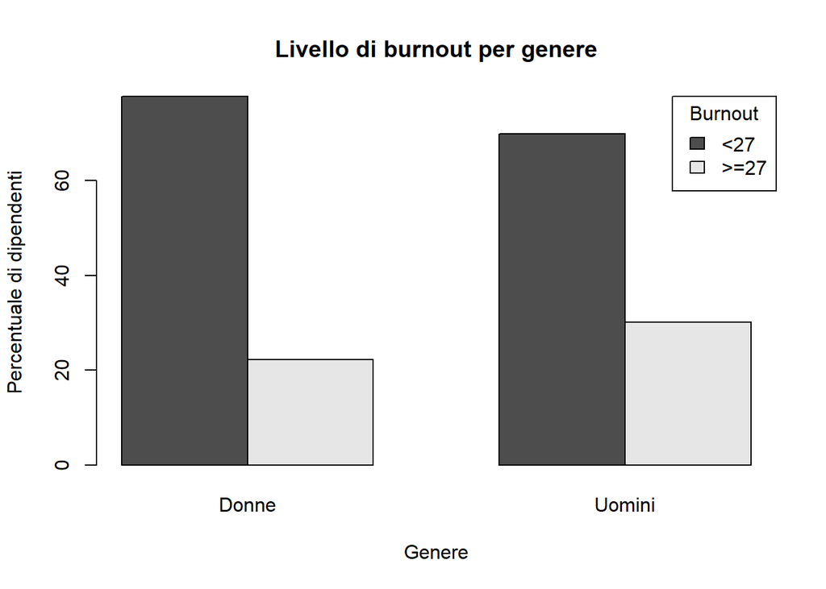

```r
barplot(t(perc_gen),
        beside = TRUE,
        names.arg = c("Donne", "Uomini"),
        legend.text = TRUE,
        args.legend = list(title = "Burnout", x = "topright"),
        xlab = "Genere",
        ylab = "Percentuale di dipendenti",
        main = "Livello di burnout per genere")
```

```r
chi2_gen = chisq.test(tab_gen)$statistic
chi2_gen
```

```
X-squared
 1.205761
```

```r
chi2max_gen = nrow(dati) * min(c(nrow(tab_gen) - 1, ncol(tab_gen) - 1))
chi2norm_gen = chi2_gen / chi2max_gen
chi2norm_gen
```

```
  X-squared
0.006028805
```

Ha un burnout alto il 22.2% delle donne e il 30.1% degli uomini: la differenza è piccola e il grafico mostra barre simili nei due gruppi. Il $\chi^2$ normalizzato (0.006) è molto vicino a 0: l’associazione tra genere e livello di burnout è praticamente nulla.

Nota: per le tabelle $2 \times 2$ la funzione `chisq.test()` applica di default la correzione di continuità di Yates, per cui il valore è un po’ più basso di quello calcolato a mano con la formula del $\chi^2$. Il valore senza correzione si ottiene con `chisq.test(tab_gen, correct = FALSE)$statistic`.

## 6.7

*Quale delle due variabili, anzianità o genere, è più associata al livello di burnout?*

```r
chi2norm_anz
```

```
X-squared
0.1921452
```

```r
chi2norm_gen
```

```
  X-squared
0.006028805
```

Il $\chi^2$ normalizzato si può usare per confrontare tabelle di dimensioni diverse. L’anzianità (0.192) è molto più associata al livello di burnout rispetto al genere (0.006), coerentemente con quanto visto nei boxplot della sezione precedente.

## 6.8

*Rappresentare graficamente la relazione tra supporto sociale e burnout. Che direzione ha la relazione?*

Le due variabili sono quantitative: la relazione si rappresenta con un diagramma di dispersione.

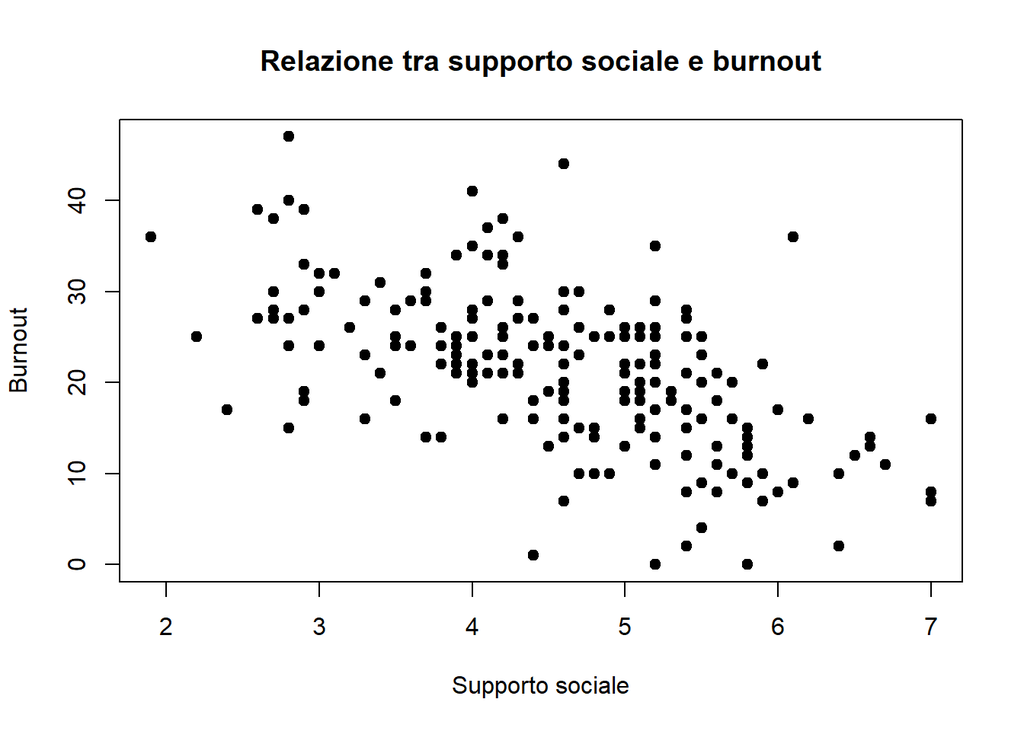

```r
plot(dati$supporto_sociale, dati$burnout,
     pch = 19,
     xlab = "Supporto sociale",
     ylab = "Burnout",
     main = "Relazione tra supporto sociale e burnout")
```

La nuvola di punti ha un andamento lineare decrescente: all’aumentare del supporto sociale il burnout tende a diminuire. La relazione è negativa.

## 6.9

*Quanto è forte la relazione lineare tra supporto sociale e burnout? Interpretare il risultato.*

La covarianza indica la direzione della relazione, ma il suo valore dipende dalle unità di misura delle variabili e quindi non dice quanto la relazione è forte. Per l’intensità si usa il coefficiente di correlazione di Pearson, che varia tra $-1$ e $1$.

```r
cov(dati$supporto_sociale, dati$burnout)
```

```
[1] -5.028724
```

```r
r_sup = cor(dati$supporto_sociale, dati$burnout)
r_sup
```

```
[1] -0.565818
```

La covarianza è negativa e conferma la direzione osservata nel grafico. La correlazione è $r =$ -0.57: la relazione lineare tra supporto sociale e burnout è negativa e di intensità moderata. I dipendenti che percepiscono più supporto da colleghi e superiori tendono ad avere livelli di esaurimento emotivo più bassi.

## 6.10

*Quanto è forte la relazione lineare tra anni di servizio e burnout? E tra età e anni di servizio?*

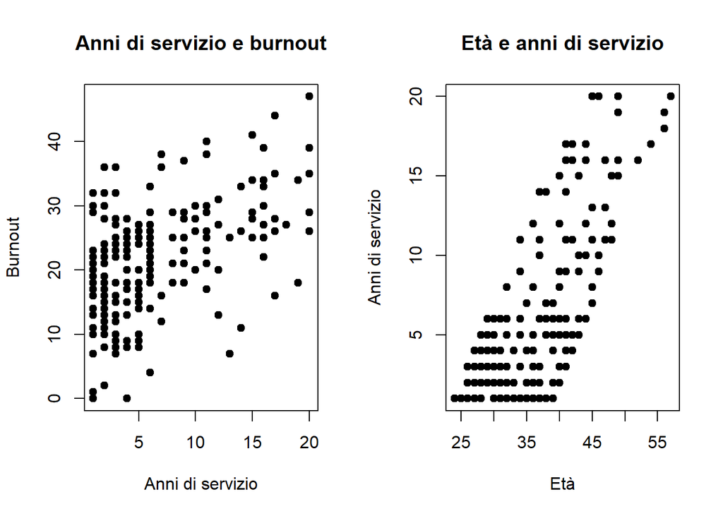

```r
par(mfrow = c(1, 2))
plot(dati$anni_servizio, dati$burnout,
     pch = 19,
     xlab = "Anni di servizio",
     ylab = "Burnout",
     main = "Anni di servizio e burnout")
plot(dati$eta, dati$anni_servizio,
     pch = 19,
     xlab = "Età",
     ylab = "Anni di servizio",
     main = "Età e anni di servizio")
```

```r
par(mfrow = c(1, 1))

r_anni = cor(dati$anni_servizio, dati$burnout)
r_anni
```

```
[1] 0.5048116
```

```r
cor(dati$eta, dati$anni_servizio)
```

```
[1] 0.6949827
```

La correlazione tra anni di servizio e burnout è $r =$ 0.5: la relazione è positiva e di intensità moderata, chi lavora da più anni in azienda tende ad avere un burnout più alto. La correlazione tra età e anni di servizio ($r =$ 0.69) è positiva e forte, come ci si aspetta: per lavorare da molti anni in azienda bisogna avere un’età più alta.

## 6.11

*Stimare un modello di regressione lineare (chiamato `m1`) per prevedere il burnout a partire dal supporto sociale. Aggiungere la retta di regressione al grafico a dispersione.*

Il burnout è la variabile dipendente ($y$), il supporto sociale la variabile indipendente ($x$).

```r
m1 = lm(burnout ~ supporto_sociale, data = dati)
m1
```

```
Call:
lm(formula = burnout ~ supporto_sociale, data = dati)

Coefficients:
     (Intercept)  supporto_sociale
          42.894            -4.695
```

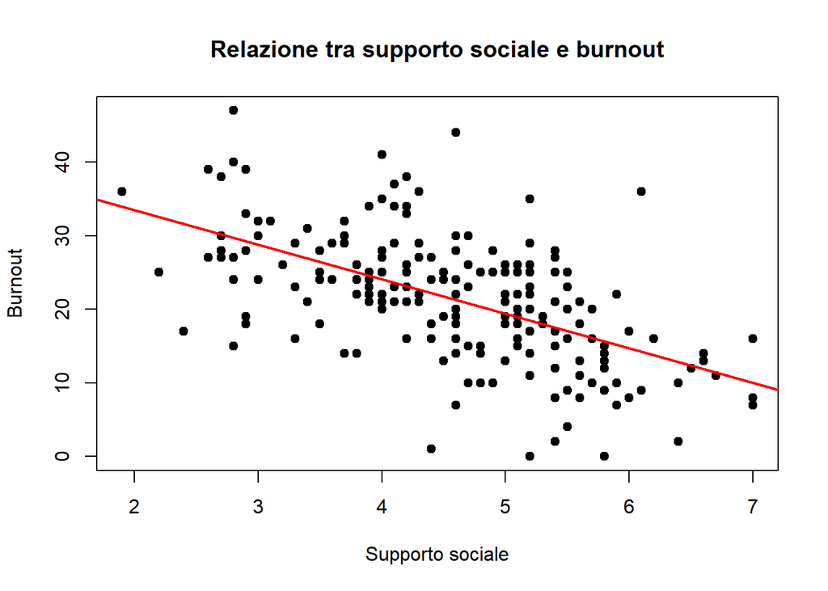

```r
plot(dati$supporto_sociale, dati$burnout,
     pch = 19,
     xlab = "Supporto sociale",
     ylab = "Burnout",
     main = "Relazione tra supporto sociale e burnout")
abline(m1, col = "red", lwd = 2)
```

### 6.11.1

*Scrivere l’equazione della retta di regressione nella forma $y^* = a + b x$ e interpretare intercetta e coefficiente angolare. Qual è il punteggio di burnout atteso per un dipendente con supporto sociale pari a 2? Per un dipendente con supporto sociale pari a 6?*

```r
a1 = coef(m1)[1]
b1 = coef(m1)[2]
a1
```

```
(Intercept)
   42.89352
```

```r
b1
```

```
supporto_sociale
       -4.695358
```

L’equazione della retta è:

$$y^* = 42.89 -4.7x$$

- **Intercetta** ($a =$ 42.89): è il burnout atteso per un dipendente con supporto sociale pari a 0. Dato che il punteggio di supporto sociale va da 1 a 7, il valore 0 non è possibile e l’intercetta non ha un significato concreto.
- **Coefficiente angolare** ($b =$ -4.7): per ogni punto in più di supporto sociale, il burnout atteso diminuisce di 4.7 punti.

```r
a1 + b1 * c(2, 6)
```

```
[1] 33.50280 14.72137
```

Il burnout atteso è 33.5 per un dipendente con supporto sociale pari a 2 e 14.72 per un dipendente con supporto sociale pari a 6. La differenza tra i due valori (18.78 punti) è pari a 4 volte il coefficiente angolare, perché i due dipendenti differiscono di 4 punti di supporto sociale.

### 6.11.2

*Quale quota della variabilità del burnout è spiegata dal supporto sociale?*

```r
R2_m1 = cor(dati$supporto_sociale, dati$burnout)^2
R2_m1
```

```
[1] 0.32015
```

Il supporto sociale spiega il 32% della variabilità del burnout ($R^2 =$ 0.32). Il restante 68% dipende da altri fattori non considerati nel modello.

## 6.12

*Studiare il comportamento dei residui del modello di regressione utilizzando un’opportuna rappresentazione grafica.*

I residui sono le differenze tra i valori osservati e quelli stimati dal modello ($y - y^*$).

```r
res_m1 = residuals(m1)
# equivalente a: dati$burnout - fitted(m1)
summary(res_m1)
```

```
    Min.  1st Qu.   Median     Mean  3rd Qu.     Max.
-21.2339  -4.1121  -0.5601   0.0000   4.1272  22.7051
```

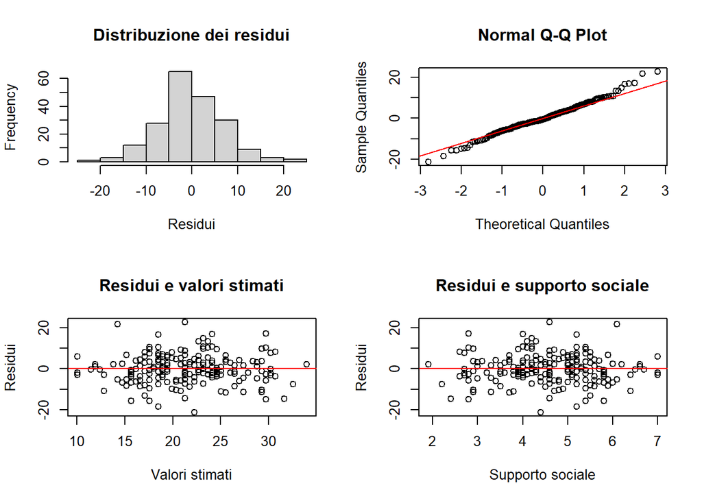

```r
par(mfrow = c(2, 2))

hist(res_m1, xlab = "Residui", main = "Distribuzione dei residui")

qqnorm(res_m1)
qqline(res_m1, col = "red")

plot(fitted(m1), res_m1,
     xlab = "Valori stimati", ylab = "Residui",
     main = "Residui e valori stimati")
abline(h = 0, col = "red")

plot(dati$supporto_sociale, res_m1,
     xlab = "Supporto sociale", ylab = "Residui",
     main = "Residui e supporto sociale")
abline(h = 0, col = "red")
```

```r
par(mfrow = c(1, 1))
```

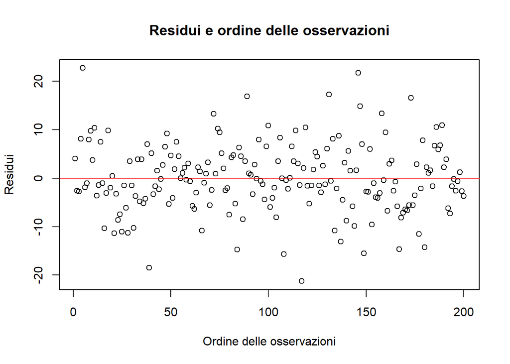

```r
plot(1:nrow(dati), res_m1,
     xlab = "Ordine delle osservazioni", ylab = "Residui",
     main = "Residui e ordine delle osservazioni")
abline(h = 0, col = "red")
```

I residui hanno media 0 e una distribuzione approssimativamente simmetrica e normale (l’istogramma ha una forma a campana e nel Q-Q plot i punti sono vicini alla retta). Nei grafici di dispersione i residui sono distribuiti in modo casuale intorno allo 0, senza andamenti particolari e con una variabilità simile per tutti i valori di supporto sociale e per tutto l’ordine delle osservazioni. Il modello lineare è quindi adeguato a descrivere la relazione.

## 6.13

*Stimare un secondo modello di regressione (`m2`) per prevedere il burnout a partire dagli anni di servizio e ripetere tutti i punti legati al modello di regressione precedente.*

```r
m2 = lm(burnout ~ anni_servizio, data = dati)
m2
```

```
Call:
lm(formula = burnout ~ anni_servizio, data = dati)

Coefficients:
  (Intercept)  anni_servizio
       15.952          0.842
```

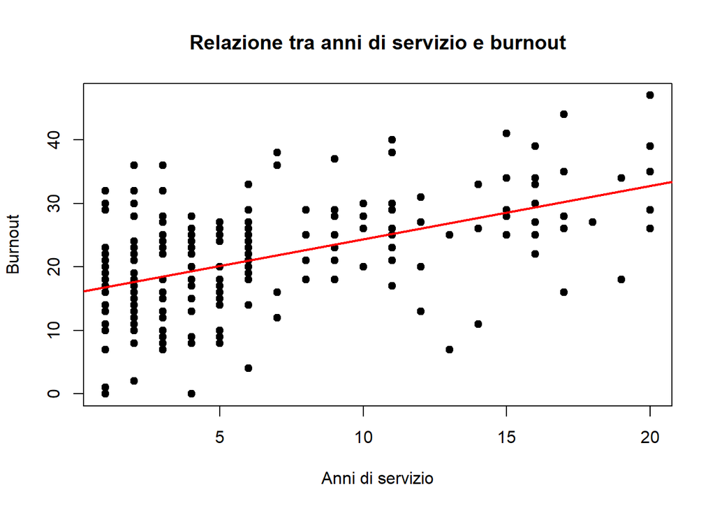

```r
plot(dati$anni_servizio, dati$burnout,
     pch = 19,
     xlab = "Anni di servizio",
     ylab = "Burnout",
     main = "Relazione tra anni di servizio e burnout")
abline(m2, col = "red", lwd = 2)
```

**Equazione e interpretazione**

```r
a2 = coef(m2)[1]
b2 = coef(m2)[2]
a2
```

```
(Intercept)
   15.95157
```

```r
b2
```

```
anni_servizio
    0.8420245
```

$$y^* = 15.95 + 0.84x$$

- **Intercetta** ($a =$ 15.95): è il burnout atteso per un dipendente con 0 anni di servizio, cioè appena assunto. Nel dataset il valore minimo di anni di servizio è 1, quindi l’intercetta è un’estrapolazione appena fuori dai dati osservati.
- **Coefficiente angolare** ($b =$ 0.84): per ogni anno di servizio in più, il burnout atteso aumenta di 0.84 punti.

Dato che la consegna chiede di ripetere tutti i punti, si calcolano anche i valori attesi per 2 e 6 anni di servizio:

```r
a2 + b2 * c(2, 6)
```

```
[1] 17.63562 21.00372
```

**Quota di variabilità spiegata**

```r
R2_m2 = cor(dati$anni_servizio, dati$burnout)^2
R2_m2
```

```
[1] 0.2548348
```

Gli anni di servizio spiegano il 25.5% della variabilità del burnout, meno del supporto sociale (32%): tra i due, il modello `m1` è quello che descrive meglio il burnout.

**Residui**

```r
res_m2 = residuals(m2)
summary(res_m2)
```

```
      Min.    1st Qu.     Median       Mean    3rd Qu.       Max.
-19.897891  -4.319670  -0.003719   0.000000   4.747047  18.364379
```

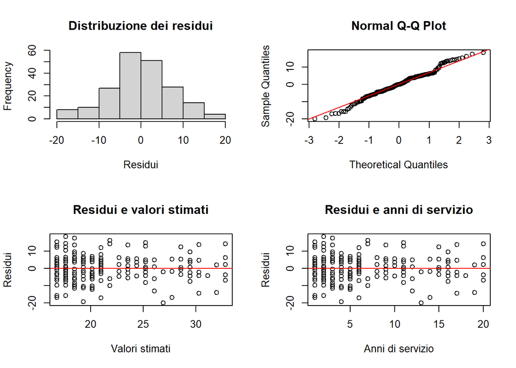

```r
par(mfrow = c(2, 2))

hist(res_m2, xlab = "Residui", main = "Distribuzione dei residui")

qqnorm(res_m2)
qqline(res_m2, col = "red")

plot(fitted(m2), res_m2,
     xlab = "Valori stimati", ylab = "Residui",
     main = "Residui e valori stimati")
abline(h = 0, col = "red")

plot(dati$anni_servizio, res_m2,
     xlab = "Anni di servizio", ylab = "Residui",
     main = "Residui e anni di servizio")
abline(h = 0, col = "red")
```

```r
par(mfrow = c(1, 1))
```

Anche in questo caso i residui sono distribuiti in modo approssimativamente simmetrico intorno allo 0. Nei grafici di dispersione i punti si dispongono in colonne verticali perché gli anni di servizio sono numeri interi, ma non si vedono andamenti sistematici: i residui restano distribuiti in modo casuale intorno allo 0.